# Winter5 冬第5周上机内容

ChenXG 陈栩淦 3160104014

12/18/2018

```r
Sys.setlocale("LC_ALL", locale = "en_US.UTF-8")
```

```
## [1] "en_US.UTF-8/en_US.UTF-8/en_US.UTF-8/C/en_US.UTF-8/en_US.UTF-8"
```

```r
setwd("~/Project/RegressionAnalysis")
```

```r
library(leaps)  # for leaps and regsubsets
library(faraway)  # for Cpplot
library(DAAG)  # for press
```

## 题1

中国旅游业的现状分析：国内旅游市场收入$y$（亿元）收到许多因素的影响，我们选取如下的5个因素进行研究：

- $x_1$：国内旅游人数（万人次）；
- $x_2$：城镇居民平均旅游支出（元）；
- $x_3$：乡村居民人均旅游支出（元）；
- $x_4$：公路里程（万公里）；
- $x_5$：铁路里程（万公里）。

根据《中国统计年鉴》，我们收集了1994-2010年度数据，如下表。试做自变量选择的分析。

```r
y <- c(1023.5, 1375.7, 1638.4, 2112.7, 2391.2, 2831.9, 3175.5, 3522.4, 3878.4,
       3442.3, 4710.7, 5285.86, 6229.74, 7000.62, 8749.3, 10183.69, 12579.77)
x1 <- c(52400, 62900, 63900, 64400, 69450, 71900, 74400, 78400, 87800,
        87000, 110200, 121200, 139400, 161000, 171200, 190200, 210300)
x2 <- c(414.7, 464, 534.1, 599.8, 607, 614.8, 678.6, 708.3, 739.7,
        684.9, 731.8, 737.1, 766.4, 906.9, 849.4, 801.1, 833)
x3 <- c(54.9, 61.5, 70.5, 145.7, 197, 249.5, 226.6, 212.7, 209.1,
        200, 210.2, 227.6, 221.9, 222.5, 275.3, 295.3, 206)
x4 <- c(111.78, 115.7, 118.58, 122.64, 127.85, 135.17, 140.27, 169.8, 176.52,
        180.98, 187.07, 334.52, 345.7, 358.37, 373.02, 386.08, 400.83)
x5 <- c(5.9, 5.97, 6.49, 6.6, 6.64, 6.74, 6.87, 7.01, 7.19,
        7.3, 7.44, 7.54, 7.71, 7.8, 7.97, 8.55, 9.12)

data <- data.frame(y, x1, x2, x3, x4, x5)

datascale <- scale(data)
datascale
```

```
##                   y          x1          x2          x3         x4
##  [1,] -1.1256265405 -1.09151318 -2.02054480 -1.96673681 -0.9840687
##  [2,] -1.0181924238 -0.88093755 -1.65413880 -1.87295531 -0.9492721
##  [3,] -0.9380591402 -0.86088272 -1.13314366 -1.74507145 -0.9237073
##  [4,] -0.7933799762 -0.85085531 -0.64485007 -0.67653072 -0.8876680
##  [5,] -0.7084271042 -0.74957846 -0.59133845  0.05240731 -0.8414205
##  [6,] -0.5739971916 -0.70044415 -0.53336752  0.79839652 -0.7764432
##  [7,] -0.4691863951 -0.65030709 -0.05919505  0.47300313 -0.7311721
##  [8,] -0.3633689758 -0.57008781  0.16154041  0.27549361 -0.4690437
##  [9,] -0.2547757176 -0.38157248  0.39491056  0.22434006 -0.4093925
## [10,] -0.3878024589 -0.39761634 -0.01237238  0.09503526 -0.3698025
## [11,] -0.0008932208  0.06765553  0.33619641  0.23997031 -0.3157435
## [12,]  0.1745519994  0.28825857  0.37558691  0.48721245  0.9931229
## [13,]  0.4624705517  0.65325633  0.59334950  0.40621933  1.0923642
## [14,]  0.6976176610  1.08644049  1.63756943  0.41474492  1.2048317
```

[output cut: 31 more lines]

```r
data2 <- data.frame(datascale)

X <- as.matrix(data2[, 2:6])
y <- as.matrix(data2[, 1])
```

### 调整后的$R^2$准则

```r
adjr <- leaps(X, y, int = T, method = "adjr2")
adjr
```

```
## $which
##       1     2     3     4     5
## 1  TRUE FALSE FALSE FALSE FALSE
## 1 FALSE FALSE FALSE FALSE  TRUE
## 1 FALSE FALSE FALSE  TRUE FALSE
## 1 FALSE  TRUE FALSE FALSE FALSE
## 1 FALSE FALSE  TRUE FALSE FALSE
## 2  TRUE FALSE FALSE FALSE  TRUE
## 2  TRUE FALSE FALSE  TRUE FALSE
## 2  TRUE FALSE  TRUE FALSE FALSE
## 2  TRUE  TRUE FALSE FALSE FALSE
## 2 FALSE FALSE FALSE  TRUE  TRUE
## 2 FALSE FALSE  TRUE FALSE  TRUE
## 2 FALSE  TRUE FALSE FALSE  TRUE
## 2 FALSE  TRUE FALSE  TRUE FALSE
```

[output cut: 32 more lines]

```r
adjr$which[which.max(adjr$adjr2),]
```

```
##    1    2    3    4    5
## TRUE TRUE TRUE TRUE TRUE
```

利用调整后的$R^2$准则，最终选择自变量子集：$\{x_1, x_2, x_3, x_4, x_5\}$.

### $C_p$准则

```r
cp <- leaps(X, y, int = T, method = "Cp")
cp
```

```
## $which
##       1     2     3     4     5
## 1  TRUE FALSE FALSE FALSE FALSE
## 1 FALSE FALSE FALSE FALSE  TRUE
## 1 FALSE FALSE FALSE  TRUE FALSE
## 1 FALSE  TRUE FALSE FALSE FALSE
## 1 FALSE FALSE  TRUE FALSE FALSE
## 2  TRUE FALSE FALSE FALSE  TRUE
## 2  TRUE FALSE FALSE  TRUE FALSE
## 2  TRUE FALSE  TRUE FALSE FALSE
## 2  TRUE  TRUE FALSE FALSE FALSE
## 2 FALSE FALSE FALSE  TRUE  TRUE
## 2 FALSE FALSE  TRUE FALSE  TRUE
## 2 FALSE  TRUE FALSE FALSE  TRUE
## 2 FALSE  TRUE FALSE  TRUE FALSE
```

[output cut: 33 more lines]

```r
cp$which[which.min(cp$Cp), ]
```

```
##     1     2     3     4     5
##  TRUE  TRUE FALSE  TRUE  TRUE
```

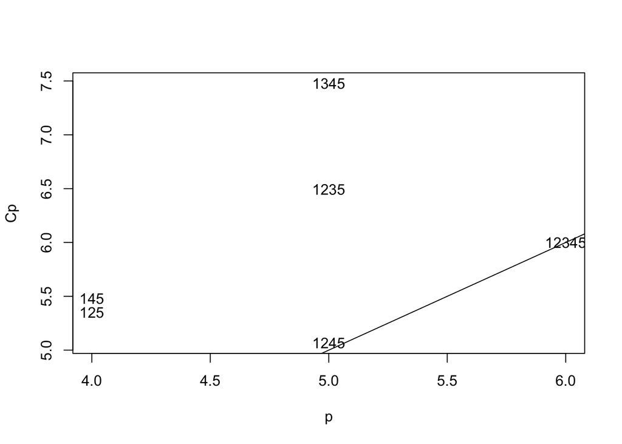

```r
Cpplot(cp)
```

根据$C_p$准则，最终选择自变量子集：$\{x_1, x_2, x_4, x_5\}$.

### 其他准则

```r
calcuPress <- function(data2, var){
  varnameList <- colnames(data2)
  varnameList <- varnameList[- which(varnameList == "y")]
  modelnum <- length(var[,1])

  press.f <- numeric(15)
  for (i in 1: modelnum){
    formu <- paste("y~", paste(varnameList[var[i,]], collapse = "+"))
    model <- lm(formu, data = data2)
    press.f[i] = press(model)
  }

  return (press.f)
}


calcuCriteria <- function(data2){
  nbest <- 2 ^ (length(data2[1,]) - 1) - 1
  search.results <- regsubsets(y~., data = data2,
                               method = "exhaustive", nbest = nbest)
  selection.criteria <- summary(search.results)

  n <- length(data2[, 1])
  q <- as.integer(row.names(selection.criteria$which))
  R.sq <- selection.criteria$rsq
  AdjR.sq <- selection.criteria$adjr2
  rms <- selection.criteria$rss / (n - q - 1)
  Cp <- selection.criteria$cp
  aic.f <- n * log(selection.criteria$rss) + 2 * (q + 1)
  bic.f <- n * log(selection.criteria$rss) + (q + 1) * log(n)
  var <- as.matrix(selection.criteria$which[, 2:6])
  press.f <- calcuPress(data2, var)
  criteria.table <- data.frame(cbind(q, rms, R.sq, AdjR.sq, Cp, aic.f, bic.f, press.f,
                                     var[,1], var[,2], var[,3], var[,4], var[,5]),
                               row.names = NULL)
  names(criteria.table) <- c("q", "RMS", "Rsq", "aRsq", "Cp", "AIC", "BIC", "PRESS",
                             "x1", "x2", "x3", "x4", "x5")
  return (criteria.table)
}
```

```r
criteria.table <- calcuCriteria(data2)
round(criteria.table, 2)
```

```
##    q  RMS  Rsq aRsq     Cp    AIC    BIC PRESS x1 x2 x3 x4 x5
## 1  1 0.03 0.97 0.97  17.57  -9.60  -7.93  0.68  1  0  0  0  0
## 2  1 0.06 0.94 0.94  52.13   3.27   4.93  1.34  0  0  0  0  1
## 3  1 0.15 0.86 0.85 140.74  17.87  19.53  3.24  0  0  0  1  0
## 4  1 0.35 0.67 0.65 341.76  32.08  33.75  7.06  0  1  0  0  0
## 5  1 0.63 0.41 0.37 630.28  42.20  43.87 11.20  0  0  1  0  0
## 6  2 0.02 0.98 0.98   8.39 -15.33 -12.83  0.50  1  0  0  0  1
## 7  2 0.02 0.98 0.98  12.24 -12.25  -9.75  0.60  1  0  0  1  0
## 8  2 0.03 0.97 0.97  17.80  -8.61  -6.11  0.89  1  0  1  0  0
## 9  2 0.03 0.97 0.97  19.56  -7.60  -5.10  0.86  1  1  0  0  0
## 10 2 0.05 0.95 0.95  38.99   0.77   3.27  1.36  0  0  0  1  1
## 11 2 0.06 0.95 0.94  47.04   3.31   5.81  1.28  0  0  1  0  1
## 12 2 0.06 0.95 0.94  47.07   3.31   5.81  1.32  0  1  0  0  1
## 13 2 0.15 0.87 0.85 134.73  18.96  21.46  3.37  0  1  0  1  0
## 14 2 0.15 0.87 0.85 135.72  19.07  21.57  3.52  0  0  1  1  0
```

[output cut: 17 more lines]

#### $AIC$准则

```r
criteria.table[which.min(criteria.table[,'AIC']),]
```

```
##    q        RMS       Rsq      aRsq       Cp       AIC       BIC     PRESS
## 26 4 0.01478558 0.9889108 0.9852144 5.065969 -19.39634 -15.23027 0.4122183
##    x1 x2 x3 x4 x5
## 26  1  1  0  1  1
```

可以得到，根据$AIC$准则，我们选择自变量子集：$\{x_1, x_2, x_4, x_5\}$.

#### $BIC$准则

```r
criteria.table[which.min(criteria.table[,'BIC']),]
```

```
##    q        RMS       Rsq      aRsq       Cp       AIC       BIC     PRESS
## 26 4 0.01478558 0.9889108 0.9852144 5.065969 -19.39634 -15.23027 0.4122183
##    x1 x2 x3 x4 x5
## 26  1  1  0  1  1
```

可以得到，根据$BIC$准则，我们同样选择自变量子集：$\{x_1, x_2, x_4, x_5\}$.

#### $PRESS$准则

```r
criteria.table[which.min(criteria.table[,'PRESS']),]
```

```
##    q        RMS       Rsq      aRsq       Cp       AIC       BIC     PRESS
## 26 4 0.01478558 0.9889108 0.9852144 5.065969 -19.39634 -15.23027 0.4122183
##    x1 x2 x3 x4 x5
## 26  1  1  0  1  1
```

可以得到，根据$PRESS$准则，我们同样选择自变量子集：$\{x_1, x_2, x_4, x_5\}$.

### 图示法的变量选择

```r
subsets <- regsubsets(y~., data = data2)
summary(subsets)
```

```
## Subset selection object
## Call: regsubsets.formula(y ~ ., data = data2)
## 5 Variables  (and intercept)
##    Forced in Forced out
## x1     FALSE      FALSE
## x2     FALSE      FALSE
## x3     FALSE      FALSE
## x4     FALSE      FALSE
## x5     FALSE      FALSE
## 1 subsets of each size up to 5
## Selection Algorithm: exhaustive
##          x1  x2  x3  x4  x5
## 1  ( 1 ) "*" " " " " " " " "
## 2  ( 1 ) "*" " " " " " " "*"
## 3  ( 1 ) "*" "*" " " " " "*"
## 4  ( 1 ) "*" "*" " " "*" "*"
## 5  ( 1 ) "*" "*" "*" "*" "*"
```

这个结果告诉我们：如果只选择一个变量，应该选入$\{x_1\}$；若只选择两个变量，应该选入$\{x_1, x_5\}$；若选择三个变量，则应选入$\{x_1, x_2, x_5\}$；若选择四个变量，应选入$\{x_1, x_2, x_4, x_5\}$；若选入五个变量，则全部选入。

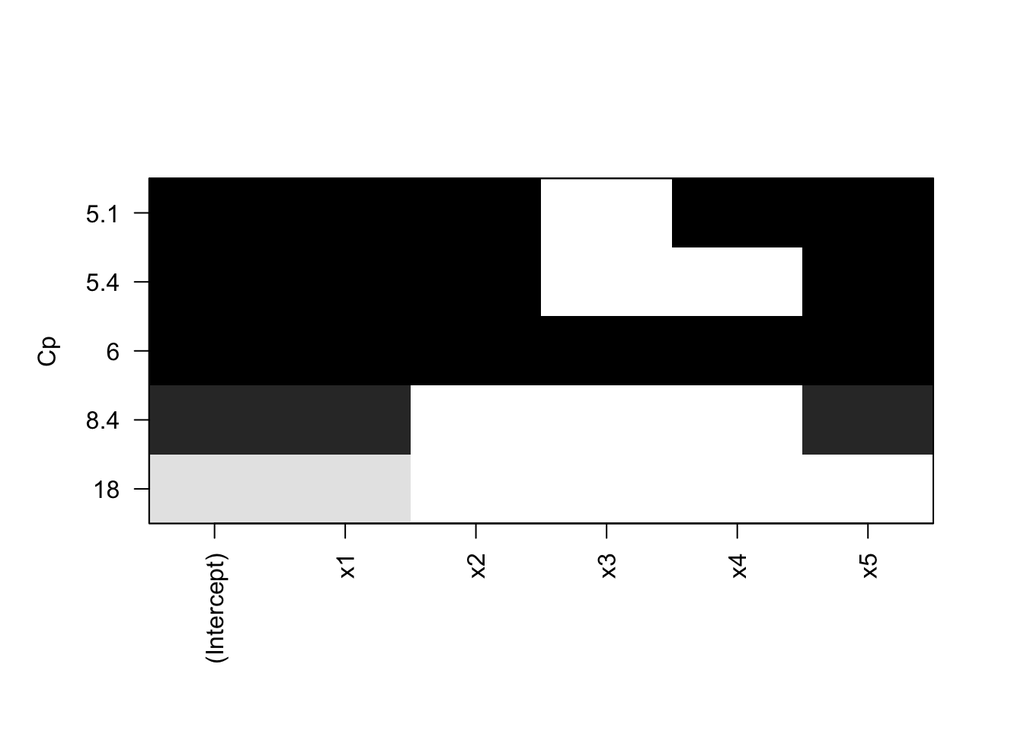

```r
plot(subsets, scale = "Cp")
```

根据$C_p$准则，最终选择自变量子集：$\{x_1, x_2, x_4, x_5\}$.

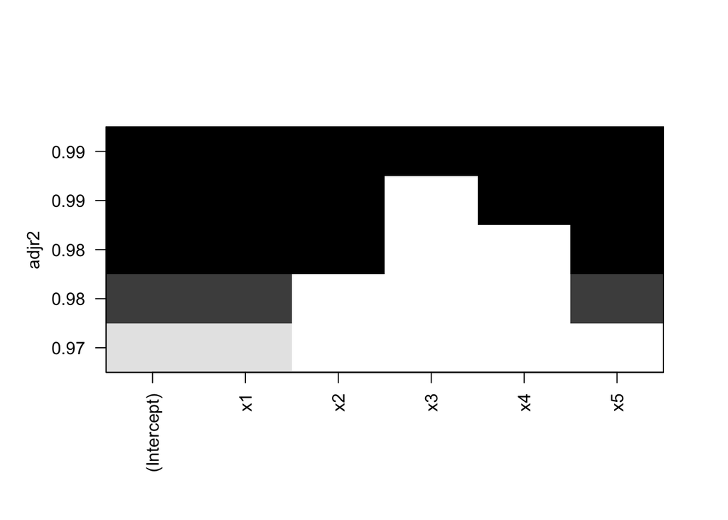

```r
plot(subsets, scale = "adjr2")
```

利用调整后的$R^2$准则，最终选择自变量子集：$\{x_1, x_2, x_3, x_4, x_5\}$.

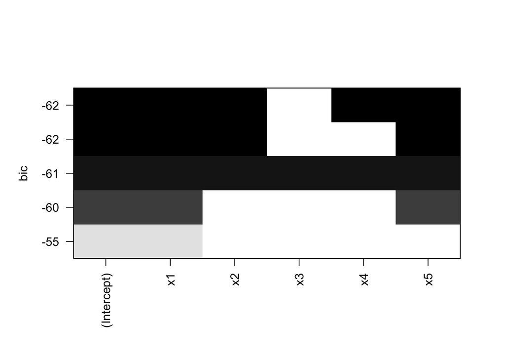

```r
plot(subsets, scale = "bic")
```

可以得到，根据$BIC$准则，我们同样选择自变量子集：$\{x_1, x_2, x_4, x_5\}$.

## 题2

对下列数据使用前进法、后退法和逐步回归法选择自变量。

数据：下表给出了我国1991-2006年猪肉价格及其影响因素的数据。在这个数据集中，$y$表示猪肉价格（元/公斤），$x_1$表示CPI，$x_2$表示人口数（亿），$x_3$表示年末存栏量（万头），$x_4$表示城镇居民可支配收入（元），$x_5$表示玉米价格（元/吨），$x_6$表示猪肉生成量（万吨）。

```r
y <- c(9.84, 10.32, 10.65, 10.49, 9.16, 10.18, 14.96, 11.81,
       10.77, 8.38, 8.74, 10.18, 9.85, 10.70, 13.97, 13.39, 14.03)
x1 <- c(103.1, 103.4, 106.4, 114.7, 124.1, 117.1, 107.9, 102.8,
        99.2, 98.6, 100.4, 100.7, 99.2, 101.2, 103.9, 101.8, 101.5)
x2 <- c(14.39, 12.98, 11.60, 11.45, 11.21, 10.55, 10.42, 10.06,
        9.14, 8.18, 7.58, 6.95, 6.45, 6.01, 5.87, 5.89, 5.28)
x3 <- c(6241, 36965, 38421, 39300, 41462, 44169, 36284, 40035,
        42256, 43020, 44682, 45743, 46292, 46602, 48189, 50335, 49441)
x4 <- c(1510.2, 1700., 2026.6, 2577.4, 3496.2, 4283.0, 4838.9, 5160.3,
        5425.1, 5854.0, 6280.0, 6859.6, 7702.8, 8472.2, 9421.6, 10493.0, 13172.0)
x5 <- c(686.7, 590.0, 625.0, 726.7, 1004.2, 1576.7, 1481.7, 1150.8,
        1269.2, 1092.5, 887.5, 1060.0, 1033.3, 1087.5, 1288.3, 1229.2, 1280.0)
x6 <- c(2281, 2452, 2635, 2854, 3205, 3648, 3158, 3596,
        3884, 3891, 4031, 4184, 4327, 4519, 4702, 5011, 5197)

data <- data.frame(y, x1, x2, x3, x4, x5, x6)

datascale <- scale(data)
datascale
```

```
##                y         x1          x2          x3           x4
##  [1,] -0.6097523 -0.2748530  1.91726000 -3.51418894 -1.326261677
##  [2,] -0.3627027 -0.2327584  1.41012336 -0.42070292 -1.268118402
##  [3,] -0.1928561  0.1881877  0.91377686 -0.27410366 -1.168067857
##  [4,] -0.2752060  1.3528052  0.85982616 -0.18560040 -0.999335953
##  [5,] -0.9597392  2.6717697  0.77350503  0.03208339 -0.717871039
##  [6,] -0.4347588  1.6895621  0.53612192  0.30464122 -0.476842966
##  [7,]  2.0254432  0.3986607  0.48936464 -0.48927029 -0.306548728
##  [8,]  0.4041804 -0.3169477  0.35988295 -0.11159596 -0.208091150
##  [9,] -0.1310937 -0.8220830  0.02898528  0.11202832 -0.126972398
## [10,] -1.3611947 -0.9062722 -0.31629924  0.18895266  0.004416698
## [11,] -1.1759075 -0.6537045 -0.53210206  0.35629330  0.134917408
## [12,] -0.4347588 -0.6116099 -0.75869503  0.46312147  0.312471897
## [13,] -0.6046054 -0.8220830 -0.93853072  0.51839825  0.570777529
## [14,] -0.1671218 -0.5414522 -1.09678612  0.54961100  0.806475292
```

[output cut: 31 more lines]

```r
data2 <- data.frame(datascale)
```

### 前进法

```r
min.model <- lm(y~1, data = data2)
fwd.model <- step(min.model, direction = "forward", scope = (~x1+x2+x3+x4+x5+x6))
```

```
## Start:  AIC=0.97
## y ~ 1
##
##        Df Sum of Sq    RSS      AIC
## + x5    1    4.1021 11.898 -2.06644
## + x4    1    4.0700 11.930 -2.02069
## + x6    1    2.1365 13.864  0.53274
## <none>              16.000  0.96938
## + x2    1    1.5803 14.420  1.20145
## + x3    1    0.7211 15.279  2.18536
## + x1    1    0.1204 15.880  2.84096
##
## Step:  AIC=-2.07
## y ~ x5
##
##        Df Sum of Sq    RSS      AIC
## <none>              11.898 -2.06644
## + x4    1   1.17650 10.721 -1.83648
## + x1    1   0.20410 11.694 -0.36059
## + x6    1   0.10621 11.792 -0.21888
## + x2    1   0.09007 11.808 -0.19562
## + x3    1   0.00737 11.891 -0.07697
```

```r
summary(fwd.model)
```

```
##
## Call:
## lm(formula = y ~ x5, data = data2)
##
## Residuals:
##      Min       1Q   Median       3Q      Max
## -1.41334 -0.55246  0.05298  0.57857  1.28766
##
## Coefficients:
##               Estimate Std. Error t value Pr(>|t|)
## (Intercept) -1.925e-16  2.160e-01   0.000   1.0000
## x5           5.063e-01  2.227e-01   2.274   0.0381 *
## ---
## Signif. codes:  0 '***' 0.001 '**' 0.01 '*' 0.05 '.' 0.1 ' ' 1
##
## Residual standard error: 0.8906 on 15 degrees of freedom
## Multiple R-squared:  0.2564, Adjusted R-squared:  0.2068
## F-statistic: 5.172 on 1 and 15 DF,  p-value: 0.03808
```

### 后退法

```r
full.model <- lm(y~., data = data2)
bwd.model <- step(full.model, direction = "backward")
```

```
## Start:  AIC=-9.56
## y ~ x1 + x2 + x3 + x4 + x5 + x6
##
##        Df Sum of Sq     RSS      AIC
## - x2    1    0.0001  4.2508 -11.5640
## - x1    1    0.0565  4.3071 -11.3400
## - x3    1    0.4131  4.6638  -9.9876
## <none>               4.2507  -9.5644
## - x5    1    2.7200  6.9706  -3.1556
## - x6    1    3.2810  7.5317  -1.8397
## - x4    1    7.3377 11.5884   5.4854
##
## Step:  AIC=-11.56
## y ~ x1 + x3 + x4 + x5 + x6
##
##        Df Sum of Sq     RSS      AIC
## - x1    1    0.0666  4.3174 -13.2996
## <none>               4.2508 -11.5640
## - x3    1    0.5419  4.7927 -11.5242
## - x5    1    3.0254  7.2762  -4.4263
## - x6    1    5.6451  9.8959   0.8013
## - x4    1    7.3386 11.5893   3.4868
##
## Step:  AIC=-13.3
## y ~ x3 + x4 + x5 + x6
##
##        Df Sum of Sq     RSS      AIC
## - x3    1    0.4753  4.7927 -13.5240
## <none>               4.3174 -13.2996
## - x5    1    3.1936  7.5109  -5.8865
## - x6    1    5.7248 10.0422  -0.9491
## - x4    1    7.3077 11.6250   1.5391
##
## Step:  AIC=-13.52
## y ~ x4 + x5 + x6
##
##        Df Sum of Sq     RSS      AIC
## <none>               4.7927 -13.5240
## - x5    1    3.1262  7.9189  -6.9873
## - x6    1    5.9287 10.7214  -1.8365
## - x4    1    6.9990 11.7917  -0.2189
```

```r
summary(bwd.model)
```

```
##
## Call:
## lm(formula = y ~ x4 + x5 + x6, data = data2)
##
## Residuals:
##      Min       1Q   Median       3Q      Max
## -0.98563 -0.40227  0.03037  0.37606  0.93932
##
## Coefficients:
##               Estimate Std. Error t value Pr(>|t|)
## (Intercept) -9.187e-17  1.473e-01   0.000 1.000000
## x4           2.707e+00  6.212e-01   4.357 0.000777 ***
## x5           5.531e-01  1.899e-01   2.912 0.012125 *
## x6          -2.585e+00  6.446e-01  -4.010 0.001483 **
## ---
## Signif. codes:  0 '***' 0.001 '**' 0.01 '*' 0.05 '.' 0.1 ' ' 1
##
## Residual standard error: 0.6072 on 13 degrees of freedom
## Multiple R-squared:  0.7005, Adjusted R-squared:  0.6313
## F-statistic: 10.13 on 3 and 13 DF,  p-value: 0.001034
```

即
$$\hat{y} = 0.001610625 \times x_4 + 0.003738866 \times x_5 - 0.005707843 \times x_6 + 18.99089.$$

### 逐步回归法

```r
min.model <- lm(y~1, data = data2)
step.model <- step(min.model, direction = "both", scope = (~x1+x2+x3+x4+x5+x6))
```

```
## Start:  AIC=0.97
## y ~ 1
##
##        Df Sum of Sq    RSS      AIC
## + x5    1    4.1021 11.898 -2.06644
## + x4    1    4.0700 11.930 -2.02069
## + x6    1    2.1365 13.864  0.53274
## <none>              16.000  0.96938
## + x2    1    1.5803 14.420  1.20145
## + x3    1    0.7211 15.279  2.18536
## + x1    1    0.1204 15.880  2.84096
##
## Step:  AIC=-2.07
## y ~ x5
##
##        Df Sum of Sq    RSS      AIC
## <none>              11.898 -2.06644
## + x4    1    1.1765 10.721 -1.83648
## + x1    1    0.2041 11.694 -0.36059
## + x6    1    0.1062 11.792 -0.21888
## + x2    1    0.0901 11.808 -0.19562
## + x3    1    0.0074 11.891 -0.07697
## - x5    1    4.1021 16.000  0.96938
```

```r
summary(step.model)
```

```
##
## Call:
## lm(formula = y ~ x5, data = data2)
##
## Residuals:
##      Min       1Q   Median       3Q      Max
## -1.41334 -0.55246  0.05298  0.57857  1.28766
##
## Coefficients:
##               Estimate Std. Error t value Pr(>|t|)
## (Intercept) -7.839e-17  2.160e-01   0.000   1.0000
## x5           5.063e-01  2.227e-01   2.274   0.0381 *
## ---
## Signif. codes:  0 '***' 0.001 '**' 0.01 '*' 0.05 '.' 0.1 ' ' 1
##
## Residual standard error: 0.8906 on 15 degrees of freedom
## Multiple R-squared:  0.2564, Adjusted R-squared:  0.2068
## F-statistic: 5.172 on 1 and 15 DF,  p-value: 0.03808
```

也就是
$$\hat{y} = 0.003422506 * x_5 + 7.386924.$$